# quiz03

Ekaterina Bochvaroska

2025-05-12

#### Load dataset

```r
my.data <- read.delim("data.txt", header = TRUE, sep = "\t", stringsAsFactors = FALSE)
x <- 9
z <- 4
my.data <- my.data[unique(c(seq(x, nrow(my.data), by=10),
                            seq(z, nrow(my.data), by=10))), ]
install.packages("pwr")
library("pwr")
```

#### Task 1: Test if Shoe Size Differs by Gender at (= 0.01)

**Hypotheses:**

- $H_0$: There is no difference in mean shoe size between males and females.

- $H_1$: There is a difference in mean shoe size between males and females.

**Justification:** A two-sample t-test is used to compare means of two independent groups (males and females). An F-test is conducted to determine if variances are equal.

```r
male_data <- my.data[my.data$Sex == "male", "Shoe.size"]
female_data <- my.data[my.data$Sex == "female", "Shoe.size"]
var.test(male_data, female_data)
```

```
##
##  F test to compare two variances
##
## data:  male_data and female_data
## F = 1.57, num df = 37, denom df = 66, p-value = 0.1097
## alternative hypothesis: true ratio of variances is not equal to 1
## 95 percent confidence interval:
##  0.9031323 2.8611782
## sample estimates:
## ratio of variances
##           1.569994
```

```r
t.test(Shoe.size ~ Sex, data = my.data, var.equal = TRUE, conf.level = 0.99)
```

```
##
##  Two Sample t-test
##
## data:  Shoe.size by Sex
## t = -15.926, df = 103, p-value < 2.2e-16
## alternative hypothesis: true difference in means between group female and group male is not equal to 0
## 99 percent confidence interval:
##  -5.234433 -3.753391
## sample estimates:
## mean in group female   mean in group male
##             38.94030             43.43421
```

```r
library("pwr")

male_data <- my.data[my.data$Sex == "male", "Shoe.size"]
female_data <- my.data[my.data$Sex == "female", "Shoe.size"]
male_mean <- mean(male_data, na.rm = TRUE)
female_mean <- mean(female_data, na.rm = TRUE)
sd_pooled <- sqrt((var(male_data, na.rm = TRUE) + var(female_data, na.rm = TRUE)) / 2)
n_male <- length(male_data[!is.na(male_data)])
pwr.t.test(n = n_male,
           d = (male_mean - female_mean) / sd_pooled,
           sig.level = 0.01, type = "two.sample", alternative = "two.sided")
```

```
##
##      Two-sample t test power calculation
##
##               n = 38
##               d = 3.131715
##       sig.level = 0.01
##           power = 1
##     alternative = two.sided
##
## NOTE: n is number in *each* group
```

**Conclusion:** The p-value (< 2.2e-16) is less than 0.01, so we reject $H_0$, concluding a significant difference in shoe size by gender. The power is approximately 1, indicating the test has a very high probability of detecting a true difference, consistent with the large effect size.

**Interpretation:** The significant result suggests gender influences shoe size, with males having a larger mean shoe size (43.43) compared to females (38.94).  
General comment on the task is that this is based on the fact I assume equal variances (based on the results of F-test) and proceed with a two-sample Student t-test , otherwise we would use Welch’s t-test if stated/proved otherwise .

## Task 2: Weight and Shoe Size Relationship

**Hypotheses (Correlation):**

- $H_0$: Weight and shoe size are not linearly correlated in the population ($\rho = 0$).

- $H_1$: Weight and shoe size are linearly correlated in the population ($\rho \neq 0$).

**Hypotheses (Regression):**

- $H_0$: Weight is not linearly dependent on shoe size ($\beta_1 = 0$).

- $H_1$: Weight is linearly dependent on shoe size ($\beta_1 \neq 0$).

**Justification:** A scatter plot with a regression line is used to visualize the relationship. Pearson’s correlation test assesses whether a linear relationship exists, while linear regression tests whether weight is predicted by shoe size. Since the task asks if weight is “linearly dependent” on shoe size, regression is the appropriate method, and correlation complements it by describing the relationship’s strength.

**Graph:**

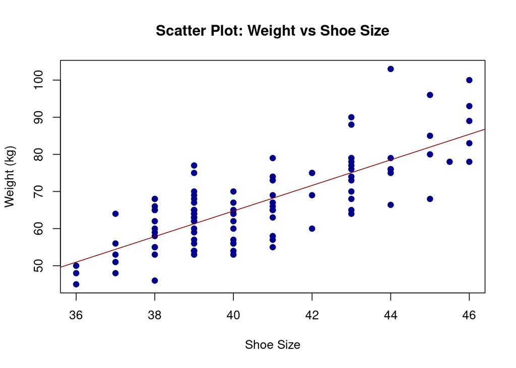

```r
plot(my.data$Shoe.size, my.data$Weight,
     xlab = "Shoe Size", ylab = "Weight (kg)",
     main = "Scatter Plot: Weight vs Shoe Size",
     pch = 19, col = "darkblue")
abline(lm(Weight ~ Shoe.size, data = my.data), col = "darkred")
```

```r
cor.test(my.data$Weight, my.data$Shoe.size, method = "pearson")
```

```
##
##  Pearson's product-moment correlation
##
## data:  my.data$Weight and my.data$Shoe.size
## t = 12.46, df = 103, p-value < 2.2e-16
## alternative hypothesis: true correlation is not equal to 0
## 95 percent confidence interval:
##  0.6855691 0.8419045
## sample estimates:
##       cor
## 0.7753532
```

```r
lm_model <- lm(Weight ~ Shoe.size, data = my.data)
summary(lm_model)
```

```
##
## Call:
## lm(formula = Weight ~ Shoe.size, data = my.data)
##
## Residuals:
##      Min       1Q   Median       3Q      Max
## -13.9591  -4.8643   0.1357   3.6936  24.4830
##
## Coefficients:
##             Estimate Std. Error t value Pr(>|t|)
## (Intercept) -72.9358    11.2288  -6.495 2.98e-09 ***
## Shoe.size     3.4421     0.2762  12.460  < 2e-16 ***
## ---
## Signif. codes:  0 '***' 0.001 '**' 0.01 '*' 0.05 '.' 0.1 ' ' 1
##
## Residual standard error: 7.249 on 103 degrees of freedom
## Multiple R-squared:  0.6012, Adjusted R-squared:  0.5973
## F-statistic: 155.3 on 1 and 103 DF,  p-value: < 2.2e-16
```

```r
library(pwr)
n <- nrow(my.data[!is.na(my.data$Weight) & !is.na(my.data$Shoe.size), ])
r <- cor(my.data$Weight, my.data$Shoe.size, use = "complete.obs")

pwr.r.test(n = n, r = r, sig.level = 0.05, alternative = "two.sided")
```

```
##
##      approximate correlation power calculation (arctangh transformation)
##
##               n = 105
##               r = 0.7753532
##       sig.level = 0.05
##           power = 1
##     alternative = two.sided
```

Conclusion:

Correlation: The p-value (< 2.2e-16) is less than 0.05, so we reject (H_0), indicating a significant linear relationship between weight and shoe size. The correlation coefficient ((r = 0.775)) indicates a strong positive relationship. Regression: The p-value for the slope (< 2.2e-16) is less than 0.05, so we reject (H_0), confirming that weight is linearly dependent on shoe size. Interpretation: The correlation ((r = 0.775)) and regression slope ((_1 = 3.442)) both confirm a strong positive linear relationship: as shoe size increases by 1 unit, weight increases by approximately 3.44 kg, on average. The scatter plot visually supports this trend with an upward-sloping regression line. The (R^2 = 0.601) indicates that 60.1% of the variability in weight is explained by shoe size. The power analysis (power = 1) indicates the test is highly sensitive to detecting this relationship, given the sample size and effect size.The task is reasonably stated, as shoe size is loosely associated with overall body size, which affects weight. However, shoe size alone is not a sufficient predictor of weight. Including variables like height, sex, or age would improve the model’s accuracy.

## Task 3: Correlation Between Weight and Sport Hours per Week

**Hypotheses:** - $H_0$: There is no monotonic relationship between weight and sport hours per week in the population ($\rho_s = 0$). - $H_1$: There is a monotonic relationship between weight and sport hours per week in the population ($\rho_s \neq 0$).

**Justification:** Spearman’s rank correlation test is used to assess a monotonic relationship (either increasing or decreasing) between weight and sport hours per week, as the task does not specify a linear relationship.

```r
cor.test(my.data$Weight, my.data$Sport..hours.per.week., method = "spearman")
```

```
##
##  Spearman's rank correlation rho
##
## data:  my.data$Weight and my.data$Sport..hours.per.week.
## S = 140671, p-value = 0.005199
## alternative hypothesis: true rho is not equal to 0
## sample estimates:
##       rho
## 0.2708342
```

```r
library(pwr)
n <- nrow(my.data[!is.na(my.data$Weight) & !is.na(my.data$Sport..hours.per.week.), ])
r_s <- cor(my.data$Weight, my.data$Sport..hours.per.week., method = "spearman", use = "complete.obs")
pwr.r.test(n = n, r = r_s, sig.level = 0.05, alternative = "two.sided")
```

```
##
##      approximate correlation power calculation (arctangh transformation)
##
##               n = 105
##               r = 0.2708342
##       sig.level = 0.05
##           power = 0.8043239
##     alternative = two.sided
```

**Conclusion:** The p-value (0.005199) is less than 0.05, so we reject $H_0$, indicating a significant monotonic relationship between weight and sport hours per week. The Spearman correlation coefficient ((_s = 0.271)) indicates a weak positive relationship. The power analysis result (0.804) supports the reliability of the test, though a slightly larger sample could increase power further for such a weak correlation.

## Task 4: Test Pet Type Distribution Against Expected

**Expected proportions:** Dog 41%, Cat 33%, Fish 10%, Other 16%  
**Hypotheses:**

- $H_0$: The observed pet type distribution matches the expected proportions (Dog 41%, Cat 33%, Fish 10%, Other 16%).

- $H_1$: The observed distribution differs from the expected proportions.

**Justification:** A chi-squared goodness-of-fit test compares the observed frequencies of pet types to the expected proportions, suitable for categorical data with a single sample.

```r
# (exclude Petno = Yes)
has_pet <- rowSums(my.data[, c("PetDog", "PetCat", "PetFish", "PetOther", "PetBird", "PetRodent")] == "Yes") > 0
pet_data <- my.data[has_pet, ]

# Count observed frequencies for relevant pet types
observed <- colSums(pet_data[, c("PetDog", "PetCat", "PetFish", "PetOther")] == "Yes")
expected_props <- c(Dog = 0.41, Cat = 0.33, Fish = 0.10, Other = 0.16)
expected <- expected_props * sum(observed)

chisq.test(x = observed, p = expected_props)
```

```
##
##  Chi-squared test for given probabilities
##
## data:  observed
## X-squared = 2.0465, df = 3, p-value = 0.5628
```

**Conclusion:** The p-value from the chi-squared test is 0.5628. Since the p-value is greater than 0.05, we fail to reject $H_0$, indicating the observed pet distribution does not significantly differ from the expected proportions of 41% dogs, 33% cats, 10% fish, and 16% other.